# iDEP: Investigating Differentially Expressed Genes

## If this site has contributed to your work, please cite our article:

Ge, S.X., Son, E.W. & Yao, R. iDEP: an integrated web application for differential expression and pathway analysis of RNA-Seq data. BMC Bioinformatics 19, 534 (2018). https://doi.org/10.1186/s12859-018-2486-6

## Summary

Read Counts data were analyzed using iDEP v2.4.4. The data was first filtered to remove reads below 0.5 CPM in at least 1 sample. Then the data was transformed with EdgeR using a pseudocount of 4. Missing values were imputed using geneMedian.

After mapping, there are 32833 unique genes in 158 samples. Of the 24127 genes passed filter, 24127 were converted to Ensembl/STRING gene IDs in our database. The remaining 0 genes were kept in the data using original IDs.

Differential expression analysis was performed using DESeq2 with an FDR cutoff of 0.1 and a minimum fold-change threshold of 2. Standard Wald test was used and independent filtering was enabled.

## Selected Comparison: Radiation_Dose_cGy100-Radiation_Dose_cGy0

Up-regulated genes: 218

Down-regulated genes: 12

## Top Up-regulated Genes

```r
if (!is.null(params$up_genes_table) && nrow(params$up_genes_table) > 0) {
  kbl(params$up_genes_table, escape = FALSE) %>%
    kable_classic(full_width = FALSE, html_font = "Cambria")
} else {
  print("No up-regulated genes found for this comparison.")
}
```

| Symbol | Ensembl ID | log2 FC | Adj. P-value | Description |
| --- | --- | --- | --- | --- |
| AT2G18270 | AT2G18270 | 24.620 | 5.46e-02 | Uncharacterized protein |
| AT1G09053 | AT1G09053 | 23.318 | 1.69e-45 | NcRNA |
| AT1G68250 | AT1G68250 | 13.395 | 5.20e-16 | Uncharacterized protein |
| AT5G54043 | AT5G54043 | 12.854 | 8.18e-04 | Uncharacterized protein |
| AT2G09785 | AT2G09785 | 11.622 | 1.72e-03 | NcRNA |
| CRU3 | AT4G28520 | 9.340 | 1.98e-05 | Cruciferin 3 |
| AT4G11393 | AT4G11393 | 4.925 | 4.95e-05 | Defensin-like (DEFL) family protein |
| AT3G07255 | AT3G07255 | 4.470 | 3.78e-04 | Nuclear transport factor 2/RNA recognition motif protein |
| AT4G28460 | AT4G28460 | 3.952 | 1.79e-03 | Uncharacterized protein |
| AT2G42560 | AT2G42560 | 3.687 | 2.54e-02 | Late embryosis abundant domain-containing protein / LEA domain-containing protein |
| NAS2 | AT5G56080 | 3.684 | 1.86e-04 | Nicotianamine synthase 2 |
| AT2G44070 | AT2G44070 | 3.370 | 5.34e-02 | NagB/RpiA/CoA transferase-like superfamily protein |
| BHLH92 | AT5G43650 | 3.050 | 1.86e-02 | Basic helix-loop-helix (bHLH) DNA-binding superfamily protein |
| AT1G71520 | AT1G71520 | 2.976 | 1.15e-05 | Integrase-type DNA-binding superfamily protein |
| AT5G57510 | AT5G57510 | 2.971 | 3.14e-05 | Cotton fiber protein |
| GEA6 | AT2G40170 | 2.926 | 6.44e-03 | Stress induced protein |
| MMP | AT1G70170 | 2.799 | 5.75e-08 | Matrix metalloproteinase |
| AT5G66780 | AT5G66780 | 2.733 | 1.64e-02 | Late embryosis abundant protein |
| LEA7 | AT1G52690 | 2.696 | 1.77e-02 | Late embryosis abundant protein (LEA) family protein |
| PLL3 | AT3G09400 | 2.681 | 4.74e-02 | Pol-like 3 |
| PDE337 | AT1G68450 | 2.678 | 3.97e-07 | VQ motif-containing protein |
| AT1G13520 | AT1G13520 | 2.627 | 6.23e-05 |  |
| ATMG01010 | ATMG01010 | 2.627 | 8.85e-02 |  |
| AT5G50360 | AT5G50360 | 2.574 | 5.05e-03 | Von willebrand factor A domain protein |
| AT3G53600 | AT3G53600 | 2.536 | 7.55e-04 | C2H2-type zinc finger family protein |
| AOX1D | AT1G32350 | 2.520 | 4.97e-02 | Alternative oxidase 1D |
| SAE1B AT5G50680 | AT5G50680 | 2.506 | 9.52e-05 | SUMO activating enzyme 1B |
| MAPKKK19 | AT5G67080 | 2.485 | 5.17e-06 | Mitogen-activated protein kinase kinase kinase 19 |
| AT1G76640 | AT1G76640 | 2.459 | 1.22e-02 | Calcium-binding EF-hand family protein |
| AT1G13480 | AT1G13480 | 2.453 | 1.60e-03 |  |
| AT1G15385 | AT1G15385 | 2.430 | 9.71e-03 | Cotton fiber protein |
| AT3G02840 | AT3G02840 | 2.413 | 1.91e-03 | ARM repeat superfamily protein |
| ZIP9 | AT4G33020 | 2.376 | 5.17e-06 | ZIP metal ion transporter family |
| AT1G07160 | AT1G07160 | 2.369 | 3.56e-04 | Protein phosphatase 2C family protein |
| IDA | AT1G68765 | 2.309 | 2.88e-03 | Putative membrane lipoprotein |
| RAP2.6 | AT1G43160 | 2.284 | 7.98e-06 | Uncharacterized protein |
| AT3G51360 | AT3G51360 | 2.245 | 9.97e-02 | Eukaryotic aspartyl protease family protein |
| AT5G49690 | AT5G49690 | 2.206 | 3.30e-05 | UDP-Glycosyltransferase superfamily protein |
| AT2G27389 | AT2G27389 | 2.193 | 2.33e-03 | Uncharacterized protein |
| AT1G58223 | AT1G58223 | 2.189 | 4.60e-02 | Uncharacterized protein |
| GPAT7 | AT5G06090 | 2.177 | 1.61e-02 | Glycerol-3-phosphate acyltransferase 7 |
| AT3G61390 | AT3G61390 | 2.146 | 6.84e-04 | RING/U-box superfamily protein |
| AT1G23052 | AT1G23052 | 2.138 | 9.21e-02 | NcRNA |
| CML37 | AT5G42380 | 2.138 | 4.50e-03 | Calmodulin like 37 |
| AT3G46080 | AT3G46080 | 2.125 | 1.05e-03 | C2H2-type zinc finger family protein |
| NRT2.6 | AT3G45060 | 2.111 | 3.47e-04 | High affinity nitrate transporter 2.6 |
| AT4G39670 | AT4G39670 | 2.098 | 2.34e-07 | Glycolipid transfer protein (GLTP) family protein |
| AGC2-1 | AT3G25250 | 2.086 | 6.23e-05 | AGC (cAMP-dependent, cGMP-dependent and protein kinase C) kinase family protein |
| AT1G28590 | AT1G28590 | 2.072 | 9.19e-02 | GDSL-like Lipase/Acylhydrolase superfamily protein |
| NAC3 AT3G15500 | AT3G15500 | 2.070 | 9.89e-04 | NAC domain containing protein 3 |

## Top Down-regulated Genes

```r
if (!is.null(params$down_genes_table) && nrow(params$down_genes_table) > 0) {
  kbl(params$down_genes_table, escape = FALSE) %>%
    kable_classic(full_width = FALSE, html_font = "Cambria")
} else {
  print("No down-regulated genes found for this comparison.")
}
```

| Symbol | Ensembl ID | log2 FC | Adj. P-value | Description |
| --- | --- | --- | --- | --- |
| AT1G04163 | AT1G04163 | -31.438 | 4.29e-34 | NcRNA |
| LpxC5 | AT1G25210 | -18.190 | 1.19e-34 | UDP-3-O-acyl N-acetylglycosamine deacetylase family protein |
| AT1G08667 | AT1G08667 | -17.060 | 2.02e-02 | NcRNA |
| AT4G08015 | AT4G08015 | -14.398 | 3.14e-05 | NcRNA |
| AT1G05333 | AT1G05333 | -11.205 | 5.17e-06 | NcRNA |
| AT1G06475 | AT1G06475 | -2.678 | 5.42e-05 | Uncharacterized protein |
| AT3G08785 | AT3G08785 | -2.561 | 2.28e-03 | NcRNA |
| AT1G21280 | AT1G21280 | -2.407 | 2.86e-07 | Copia-like polyprotein/retrotransposon |
| AT2G08060 | AT2G08060 | -2.341 | 3.82e-04 | NcRNA |
| AT2G08470 | AT2G08470 | -1.880 | 1.37e-02 | NcRNA |
| AT3G59370 | AT3G59370 | -1.219 | 3.52e-02 | Vacuolar calcium-binding protein-like protein |
| bHLH39 | AT3G56980 | -1.165 | 9.34e-02 | Basic helix-loop-helix (bHLH) DNA-binding superfamily protein |

## DEG Heatmap

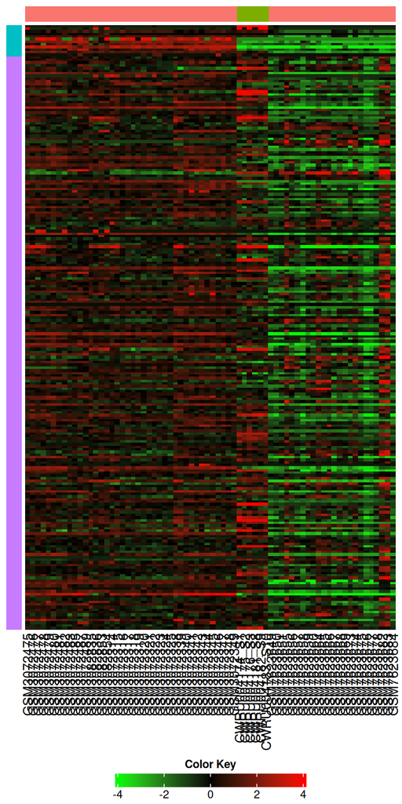

```r
if (!is.null(params$heat_data) && !is.null(params$heat_bar)) {
  heat_colors <- unlist(strsplit(params$heatmap_color_select, "-"))

  deg_heatmap(
    df = params$heat_data,
    bar = params$heat_bar,
    heatmap_color_select = heat_colors,
    cluster_rows = FALSE
  )
}
```

## Volcano Plot

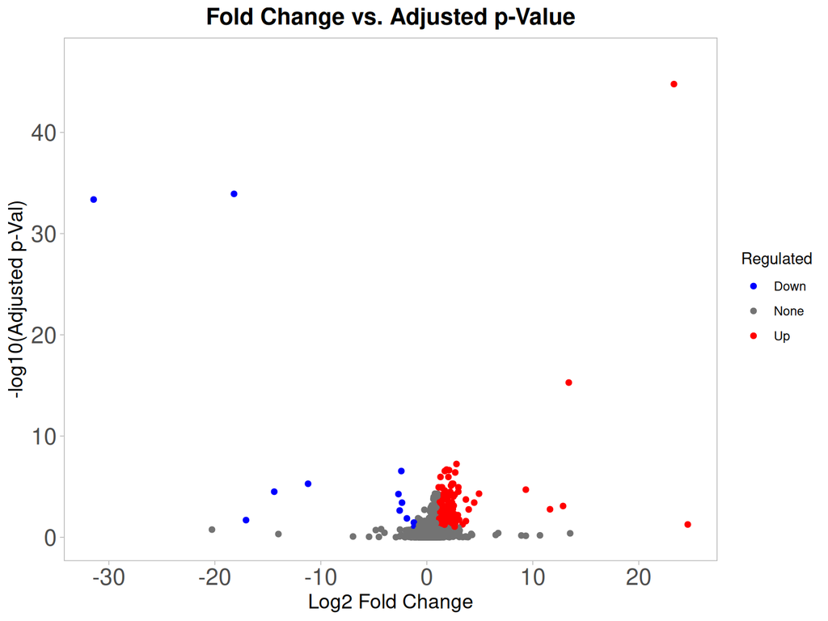

```r
if (!is.null(params$vol_data) && !is.null(params$vol_data$data)) {
  p <- plot_volcano(
    data = params$vol_data$data,
    plot_colors = params$plot_colors,
    anotate_genes = params$gene_labels_volcano
  )
  p <- refine_ggplot2(
    p = p,
    gridline = params$plot_grid_lines,
    ggplot2_theme = params$ggplot2_theme
  )
  print(p)
}
```